# 2017-10-09-scipy

## scipy에 대해 알아보자.

### scipy란?

- 과학 기술 계산용 함수 및 알고리즘을 제공한다.
- Home
  - http://www.scipy.org/
- Documentation
  - http://docs.scipy.org/doc/
- Tutorial
  - http://docs.scipy.org/doc/scipy/reference/tutorial/index.html
  - http://www.scipy-lectures.org/intro/scipy.html

### scipy subpackages

> **scipy.stats**
> - 통계 Statistics

> **scipy.constants**
> - 물리/수학 상수 Physical and mathematical constants

> **scipy.special**
> - 수학 함수 Any special mathematical functions

> **scipy.linalg**
> - 선형 대수 Linear algebra routines

> **scipy.interpolate**
> - 보간 Interpolation

> **scipy.optimize**
> - 최적화 Optimization

> **scipy.fftpack**
> - Fast Fourier transforms → 음성(소리 신호 처리)

### scipy.stats 통계

- Random Variable(확률 변수)
  - 확률 밀도 함수, 누적 확률 함수
  - 샘플 생성
  - Parameter Estimation (fitting)
- Test

### scipy.stats 에서 제공하는 확률 모형

- 지난 포스팅과 함께 보도록 하자.(아래)
  - [SciPy를 이용한 확률 분포 분석](https://namyoungkim.github.io/python/scipy/probability/2017/09/04/scipy.html)
- Documentation
  - http://docs.scipy.org/doc/scipy/reference/stats.html

#### 연속형 변수(Continuous)

- [Documentation](http://docs.scipy.org/doc/scipy/reference/tutorial/stats/continuous.html#continuous-distributions-in-scipy-stats)

| 명령어 | random variable |
| --- | --- |
| `uniform` | 균일 분포 |
| `norm` | 가우시안 정규 분포 |
| `beta` | 베타 분포 |
| `gamma` | 감마 분포 |
| `t` | 스튜던트-t분포 |
| `chi2` | 카이 제곱 분포 |
| `f` | F 분포 |
| `multivariate_normal` | 다변수 가우시안 정규 분포 |
| `dirichlet` | 디리클리 분포 |
| `wishart` | Wishart 분포 |

#### Discrete(이산형 변수)

- [Documentation](http://docs.scipy.org/doc/scipy/reference/tutorial/stats/discrete.html#discrete-distributions-in-scipy-stats)

| 명령어 | random variable |
| --- | --- |
| `bernoulli` | 베르누이 분포 |
| `binom` | 이항 분포 |
| `boltzmann` | Boltzmann (Truncated Discrete Exponential) 분포 |

### scipy.stats를 사용하려면 아래 seaborn과 함께 import를 해주어야만 실행이 된다!

```python
# -*- coding: utf-8 -*-

import scipy as sp
import seaborn as sns
import numpy as np
import matplotlib as mpl
import matplotlib.pylab as plt
%matplotlib inline
```

### random variable 사용 방법

1. 파라미터를 주고 random variable object 생성
2. method 사용

```python
rv = sp.stats.norm(loc=10, scale=10)
rv.rvs(size=(3,10), random_state=1)
```

```
array([[ 26.24345364,   3.88243586,   4.71828248,  -0.72968622,
         18.65407629, -13.01538697,  27.44811764,   2.38793099,
         13.19039096,   7.50629625],
       [ 24.62107937, -10.60140709,   6.77582796,   6.15945645,
         21.33769442,  -0.99891267,   8.27571792,   1.22141582,
         10.42213747,  15.82815214],
       [ -1.00619177,  21.4472371 ,  19.01590721,  15.02494339,
         19.00855949,   3.16272141,   8.77109774,   0.64230566,
          7.3211192 ,  15.30355467]])
```

### Common Method

| 명령어 | 설명 |
| --- | --- |
| `rvs` | 샘플 생성 |
| `pdf` | 확률 밀도 함수(연속형) |
| `pmf` | 확률 질량 함수(이산형) |
| `cdf` | 누적 확률 분포 함수 |
| `stats` | 평균, 분산, 왜도, 첨도 등 기본 통계 |
| `moment` | non-central moments of the distribution |
| `fit` | 모수 추정 |

### Remind! 왜도(skewness), 첨도(kurtosis)

- skew(왜도)
  - 분포가 어느 한쪽으로 치우쳤는지 확인
  - **왜도의 값이 +값이면 왼쪽으로 치우친다.** (- 값을 갖으면 그 반대) $$ \frac{\mu_3}{\sigma^3} = \operatorname{E}\left[\left(\frac{X-\mu}{\sigma}\right)^3 \right] $$

[figure not shown]

- kurtosis(첨도)
  - 뽀족한 정도
  - **값이 클수록 뾰족하다.** $$ \frac{\mu_4}{\sigma^4} = \frac{\operatorname{E}[(X-{\mu})^4]}{(\operatorname{E}[(X-{\mu})^2])^2} $$

[figure not shown]

### Common Parameters

| 명령어 | 설명 |
| --- | --- |
| `random_state` | 샘플 생성시 사용되는 시드(seed)값 |
| `size` | 생성하려는 샘플의 shape |
| `loc` | 일반적으로 평균의 값 |
| `scale` | 일반적으로 표준편차의 값 |

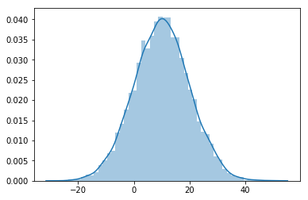

```python
sns.distplot(rv.rvs(size=10000, random_state=1))
plt.show()
```

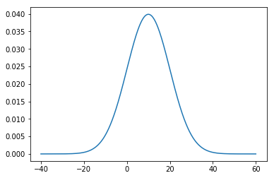

```python
# -40 ~ 60에서 1,000개 점
xx = np.linspace(-40, 60, 1000)
pdf = rv.pdf(xx)
plt.plot(xx, pdf)
plt.show()
```

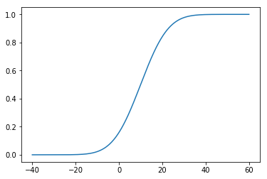

```python
cdf = rv.cdf(xx)
plt.plot(xx, cdf)
plt.show()
```

### scipy.constants 상수

**특별 상수**

- `scipy.pi`

**기타 상수**

- `scipy.constants.XXXX`

**단위**

- yotta, zetta, exa, peta, tera, giga, mega, kilo, hecto, deka
- deci, centi, milli, micro, nano, pico, femto, atto, zepto
- lb, oz, degree
- inch, foot, yard, mile, au, light_year, parsec
- hectare, acre, gallon
- mph, mach, knot

```python
sp.pi
```

```
3.141592653589793
```

```python
import scipy.constants
```

```python
# speed of light (광속의 상수)
sp.constants.c
```

```
299792458.0
```

### scipy.special 수학 함수

- Gamma, Beta, Erf, Logit
- Bessel, Legendre

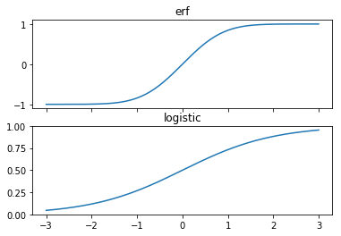

```python
x = np.linspace(-3, 3, 1000)

# erorr function
y1 = sp.special.erf(x)
a = plt.subplot(211)
plt.plot(x, y1)
plt.title("erf")
# x_tick None
a.xaxis.set_ticklabels([])

# logistic
y2 = sp.special.expit(x)
plt.subplot(212)
plt.plot(x, y2)
plt.title("logistic")
plt.show()
```

### scipy.linalg 선형대수

- inv, pinv, det

```python
# inverse(역행렬)
A = np.array([[1, 2],
              [3, 4]])
sp.linalg.inv(A)
```

```
array([[-2. ,  1. ],
       [ 1.5, -0.5]])
```

```python
# determinant
sp.linalg.det(A)
```

```
-2.0
```

### scipy.interpolate 보간

- **자료 사이의 빠진 부분을 유추**
- 1차원 보간
- 2차원 보간

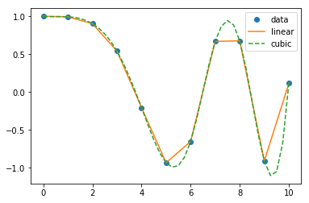

```python
# interp1d → 1차원 보간 / interp2d → 2차원 보간
from scipy.interpolate import interp1d

x = np.linspace(0, 10, num=11, endpoint=True)
y = np.cos(-x**2/9.0)

f = interp1d(x, y)
# kind='cubic' → 선형보다 부드럽게
f2 = interp1d(x, y, kind='cubic')

xnew = np.linspace(0, 10, num=41)
plt.plot(x, y, 'o', xnew, f(xnew), '-', xnew, f2(xnew), '--')
plt.legend(['data', 'linear', 'cubic'])
plt.show()
```

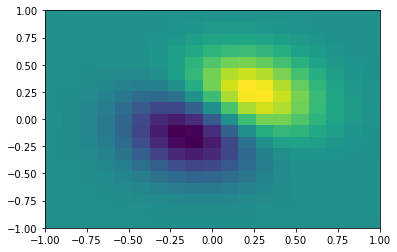

```python
# mgrid (-1, 1) 20조각으로 나눠라
## shape을 서로 맞춰준다. (가로, 세로), 3차원 그림을 그릴 때, 꼭 알아야 한다.

x, y = np.mgrid[-1:1:20j, -1:1:20j]
z = (x+y) * np.exp(-6.0*(x*x+y*y))
plt.pcolormesh(x, y, z)
plt.show()
```

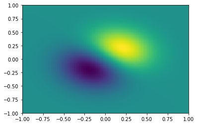

```python
# mgrid (-1, 1) 100조각으로 나눠라
xnew, ynew = np.mgrid[-1:1:100j, -1:1:100j]
tck = sp.interpolate.bisplrep(x, y, z, s=0)
znew = sp.interpolate.bisplev(xnew[:,0], ynew[0,:], tck)
plt.pcolormesh(xnew, ynew, znew)
plt.show()
```

### scipy.optimize 최적화

- 함수의 최소값 찾기

```python
from scipy import optimize
```

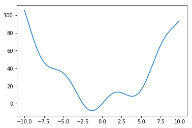

```python
def f(x):
    return x**2 + 10*np.sin(x)

# np.arange(start, end, step)
x = np.arange(-10, 10, 0.1)
plt.plot(x, f(x))
plt.show()
```

```python
# x=4부터 시작해서 최소값을 찾아라
result = optimize.minimize(f, 4)
print(result)
x0 = result['x']
x0
```

```
      fun: 8.315585579478086
 hess_inv: array([[ 0.11869202]])
      jac: array([  3.21865082e-06])
  message: 'Optimization terminated successfully.'
     nfev: 15
      nit: 3
     njev: 5
   status: 0
  success: True
        x: array([ 3.83746749])
```

```
array([ 3.83746749])
```

### 위 결과 해석

- jac : gredient
  - jac: array([ 3.21865082e-06]) → 이 정도면 충분히 작으며 '0'으로 판단
- nit: 3
- **극소값에 주의해야한다. 로컬 optimize를 주의해야 한다.**
- 위 값은 극소값을 찾았다. → x=0으로 변경하고 찾으면 바로 찾는다. 초기값을 무엇을 주느냐가 매우 중요하다!

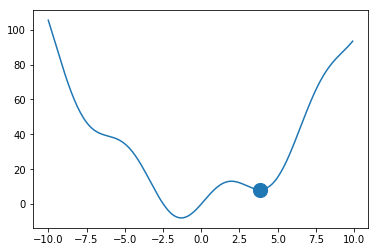

```python
plt.plot(x, f(x));
plt.hold(True)
plt.scatter(x0, f(x0), s=200)
plt.show()
```

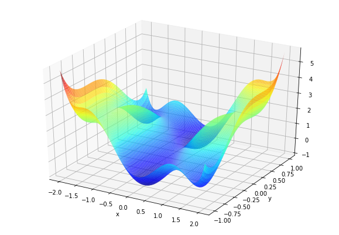

```python
from mpl_toolkits.mplot3d import Axes3D

def sixhump(x):
    return (4 - 2.1*x[0]**2 + x[0]**4 / 3.) * x[0]**2 + x[0] * x[1] + (-4 + 4*x[1]**2) * x[1] **2

x = np.linspace(-2, 2)
y = np.linspace(-1, 1)
xg, yg = np.mgrid[-2:2:100j, -1:1:100j]

plt.figure(figsize=(10, 7))

ax = plt.subplot(111, projection='3d')
ax.plot_surface(xg, yg, sixhump([xg, yg]), rstride=1, cstride=1, cmap=plt.cm.jet, linewidth=0,  alpha=0.7)
ax.set_xlabel('x')
ax.set_ylabel('y')
plt.show()
```

```python
x1 = optimize.minimize(sixhump, (1, 1))['x']
x2 = optimize.minimize(sixhump, (-1, -1))['x']
print(x1, x2)
```

```
[ 0.08984197 -0.71265635] [-0.08984198  0.71265633]
```

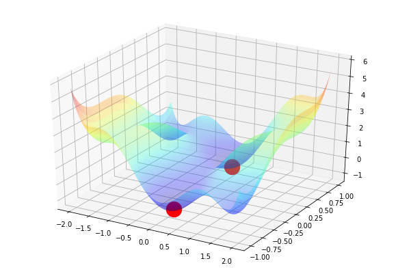

```python
plt.figure(figsize=(10, 7))

ax = plt.subplot(111, projection='3d')
ax.plot_surface(xg, yg, sixhump([xg, yg]), rstride=1, cstride=1, cmap=plt.cm.jet, linewidth=0,  alpha=0.3)
ax.scatter(x1[0], x1[1], sixhump(x1), c='r', s=500)
ax.scatter(x2[0], x2[1], sixhump(x2), c='r', s=500)
plt.show()
```

### scipy.fftpack 고속 퓨리에 변환 Fast Fourier transforms

- 신호를 주파수(frequency)영역으로 변환
  - 소리 하나를 변환
- 스펙트럼(spectrum)

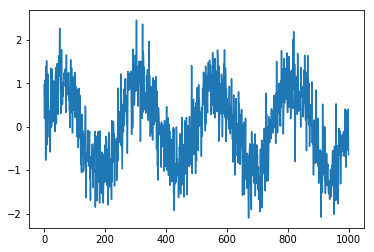

```python
time_step = 0.02
period = 5.

time_vec = np.arange(0, 20, time_step)

sig = np.sin(2 * np.pi / period * time_vec) + 0.5 * np.random.randn(time_vec.size)
plt.plot(sig)
plt.show()
```

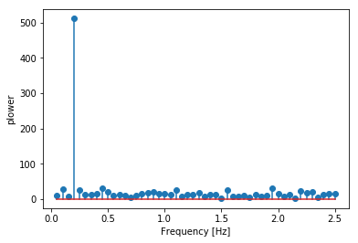

```python
import scipy.fftpack

sample_freq = sp.fftpack.fftfreq(sig.size, d=time_step)
sig_fft = sp.fftpack.fft(sig)
pidxs = np.where(sample_freq > 0)

freqs, power = sample_freq[pidxs], np.abs(sig_fft)[pidxs]
freq = freqs[power.argmax()]

plt.stem(freqs[:50], power[:50])
plt.xlabel('Frequency [Hz]')
plt.ylabel('plower')
plt.show()
```

## sympy에 추가적으로 알아보자.

- **심볼릭 연산 ← 손으로 푸는 연산을 그대로 출력한다.(사람처럼 계산한다.)**
- Mathematica와 동일한 기능
- http://www.sympy.org/

```python
import math
math.sqrt(2)
```

```
1.4142135623730951
```

```python
import sympy
from sympy import *

init_printing(use_latex='mathjax')
```

```python
sympy.sqrt(2)
```

$$\sqrt{2}$$

```python
a = Rational(1,2)
b = Rational(1,4)
a + b
```

$$\frac{3}{4}$$

```python
x, y = symbols('x y')
expr = x**2 + 2*x*y + y**2
expr
```

$$x^{2} + 2 x y + y^{2}$$

```python
# 인수분해
factor(expr)
```

$$\left(x + y\right)^{2}$$

```python
# 식 전개
expand((x + y)**3)
```

$$x^{3} + 3 x^{2} y + 3 x y^{2} + y^{3}$$

```python
x, t, z, nu = symbols('x t z nu')
expr = sin(x)*exp(x)
expr
```

$$e^{x} \sin{\left (x \right )}$$

```python
# 함수 expr를 x에 대해 미분해라.
diff(expr, x)
```

$$e^{x} \sin{\left (x \right )} + e^{x} \cos{\left (x \right )}$$

```python
# x에 대해 적분해라.
diff(expr, x)
integrate(exp(x)*sin(x) + exp(x)*cos(x), x)
```

$$e^{x} \sin{\left (x \right )}$$

### 심볼릭 연산의 장점

- 뉴럴 네크워크와 같이 여러 단계의 계산을 거치는 수치 모형에서 최종단의 필요 계산식을 컴퓨터가 직접 유도
- 수치 계산의 최적화 및 오차 감소
- theano, tensorflow
  - 자체적인 심볼릭 연산 기능